# Search Term Revenue Analysis

Alex Heaton

# Summary

This analysis was done in R and publish as HTML using knitr. I did not include the R code in the report, but if you wish to see the R code it is available [here](https://github.com/alexheat/SearchWords/blob/gh-pages/SearchWords.RMD).

### Analysis #1 Plot a Picture of the Data

After combining the csv files into one dataset, I totaled the Revenue and Clicks in each day and averaged the CPC across all the keywords. There are some anomalies in the data but I will ignore them for now. Overall, even though the clicks are increasing, the total Revenue as well as the average CPC are declining.

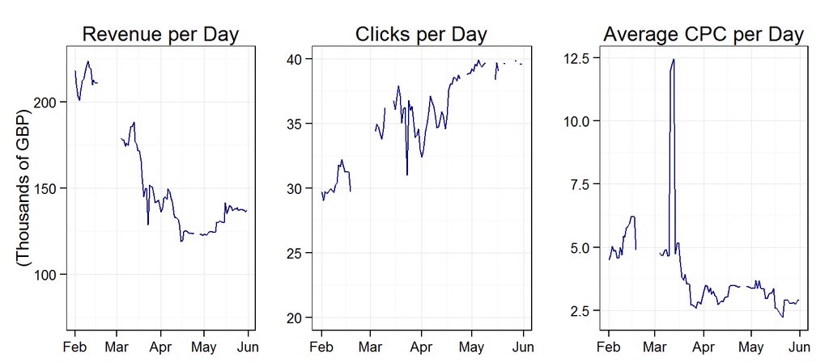

```r
by_date <- group_by(dataset, SearchDate)
date_summary <- summarize(by_date, CPC=mean(CPC), Revenue=sum(Revenue), Clicks=sum(Clicks))

Dates <- date_summary$SearchDate
Revenue <- date_summary$Revenue/1000
Clicks <- date_summary$Clicks
CPC <- date_summary$CPC


#Near zero values were distorting the chart
#Chart is easier to read if the data is left out
date_summary$Revenue[c(18:32,85:87)] <- NA

p1 <- ggplot(date_summary, aes(x=SearchDate, y=Revenue/1000)) +
  geom_line() + ggtitle("Revenue per Day") +
  ylab("(Thousands of GBP)") + xlab(NULL) + ylim(from=225/3, to=225) +
  geom_line(col="navy")

date_summary$Clicks[c(19:32, 40:43, 85:87)] <- NA
p2 <- ggplot(date_summary, aes(x=SearchDate, y=Clicks/1000)) +
  geom_line() + ggtitle("Clicks per Day") +
  ylab(NULL) + xlab(NULL) + ylim(from=40/2, to=40) +
   geom_line(col="navy")

date_summary$CPC[c(19:32, 85:87)] <- NA
p3 <- ggplot(date_summary, aes(x=SearchDate, y=CPC)) +
  geom_line() + ggtitle("Average CPC per Day") +
  ylab(NULL) + xlab(NULL) + geom_line(col="navy")

multiplot(p1, p2, p3, cols=3)
```

### Analysis #2 Identify Keywords with the Great Increases and Decreases

I wanted to see if there were any particular keywords that were causing the decline in revenue. I created totals of the revenue generated by each keyword each month. Then I plotted the difference between the February revenue and the May revenue to see what keywords declined or gained the most.

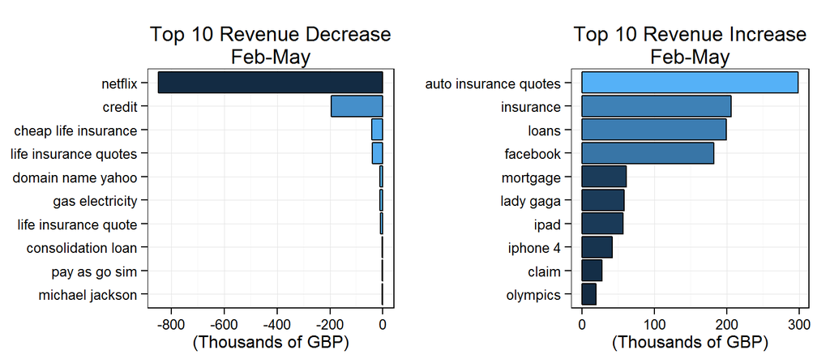

```r
by_month <- group_by(dataset, Keyword, Month=months(SearchDate))
month_summary <- summarize(by_month,  Revenue=sum(Revenue))
month_summary$Month <- factor(month_summary$Month, levels = c("February", "March", "April", "May"))
month_summary <- dcast(month_summary, Keyword ~ Month, value.var = "Revenue") #Create one collumn per month
month_summary$Change <- month_summary$May - month_summary$February

top10 <- head(arrange(month_summary, desc(Change)),10)
#Reorder the factor so it plots correctly
top10$Keyword <- revFactor(factor(top10$Keyword, levels = top10$Keyword))

bottom10 <- head(arrange(month_summary, Change),10)
#Reorder the factor so it plots correctly
bottom10$Keyword <- revFactor(factor(bottom10$Keyword, levels = bottom10$Keyword))

p1 <- ggplot(data=bottom10, aes(x=Keyword, y=Change/1000, fill=Change)) +
  geom_bar(colour="black", stat="identity")  + coord_flip() +
  theme(legend.position="none") +
  ggtitle("Top 10 Revenue Decrease\nFeb-May") +
  ylab("(Thousands of GBP)") + xlab(NULL)

p2 <- ggplot(data=top10, aes(x=Keyword, y=Change/1000, fill=Change)) +
  geom_bar(colour="black", stat="identity")  + coord_flip() +
  theme(legend.position="none") +
  ggtitle("Top 10 Revenue Increase\nFeb-May") +
  ylab("(Thousands of GBP)") + xlab(NULL)

multiplot(p1, p2, cols=2)
```

It is clear that a major source of the decline in overall revenue is caused by the decrease is revenue from the netflix.